# model

#### Forewords : Model for personnal projects in Statistics

There are some rules that you should follow in order to present your personnal project. The order of this presentation is pedagogical and should help you to go through all the commands that you may use when you start using Python for statistics. You have to follow it.

This model uses the most basic instructions. There are alternatives which are also available but you have to go through the basics before to go further. Moreover, those basic tools will help you understand new specific packages by comparing the results they produce with what you already master.

Before to start the project, you have ot make the first treatments in order that the base be clean. Do not include it in the project and provide a clean data base. Do not include eigher your attemps to get some basic information of the variables, just the minimum. Summarize those inofrmation in the introduction. Similarly, do not display your attempts to choose classes, etc. Give the final version directly.

You do not have to study all the variables but to preesent minimal statistical work from which I can check that you are able to do all the analysis tha we learned. You can also write functions, modules and packages to avoid repetition of certina operations. In this case, they should be written by you and contain no unnecessary command.

For this project Chat GPT is your enemy (and mine), your friends are my tutorials, this notebook, and the package documentations of the imported modules.

```python
import numpy as np
import pandas as pd
import scipy.stats as st
import matplotlib.pyplot as plt
```

# Cartel stability

## Part I: Description of the data

**source:** online addotional material of Stock, J.H. and Watson, M.W. (2007). Introduction to Econometrics, 2nd ed. Boston: Addison Wesley. Formerly in Porter, R. H. (1983). A Study of Cartel Stability: The Joint Executive Committee, 1880–1886. The Bell Journal of Economics, 14, 301–314.

**Description of the data:** They are weekly observations, from 1880 to 1886, on prices for transportation of grain in the Great Lakes region in the US, where transportation could be made by train or by boat depending on the weather conditions.

- *price (numerical discrete):* weekly index of price of shipping a ton of grain by rail (7 levels)
- *cartel (categorical):* Existence of an operative railroad cartel.
- *quantity (continuous):* total tonnage of grain shipped in the week. From 4,800 to 77,000 approximatively.

_ *season (categorical):* indicating season of year. To match the weekly data, the calendar has been divided into 13 periods, each approximately 4 weeks long.

- *ice (categorical):* Indicates whether the Great Lakes innavigable because of ice.

**Objective:** The data were gathered mainly to understand whether the presence of a railway Cartel would influence the level of prices.

```python
df = pd.read_csv('cartelStability.csv')
df.head()
```

|  | rownames | price | cartel | quantity | season | ice |
| --- | --- | --- | --- | --- | --- | --- |
| 0 | 1 | 0.4 | yes | 13632 | Jan 1 - Jan 28 | yes |
| 1 | 2 | 0.4 | yes | 20035 | Jan 1 - Jan 28 | yes |
| 2 | 3 | 0.4 | yes | 16319 | Jan 1 - Jan 28 | yes |
| 3 | 4 | 0.4 | yes | 12603 | Jan 1 - Jan 28 | yes |
| 4 | 5 | 0.4 | yes | 23079 | Jan 29 - Feb 25 | yes |

```python
df.describe()
```

|  | rownames | price | quantity |
| --- | --- | --- | --- |
| count | 328.000000 | 328.000000 | 328.000000 |
| mean | 164.500000 | 0.246494 | 25384.393293 |
| std | 94.829672 | 0.066526 | 11632.766249 |
| min | 1.000000 | 0.125000 | 4810.000000 |
| 25% | 82.750000 | 0.200000 | 16604.000000 |
| 50% | 164.500000 | 0.250000 | 23100.500000 |
| 75% | 246.250000 | 0.300000 | 32389.000000 |
| max | 328.000000 | 0.400000 | 76407.000000 |

## Part II: Description of some variable

For each chosen variable, one categorical, one numerical discrete and one continuous, we display the frequency table as well as two possible graphic representations. We also display the quantiles and principal moments when it means something.

```python
n = len(df)
n
```

```
328
```

### cartel

```python
x = np.array(df['cartel'][:])
```

#### Frequency table

```python
levels, ni = np.unique(x, return_counts = True)
fi = ni/n
ft = pd.DataFrame(data = np.transpose([ni, fi]), index = levels, columns = ['frequencies', 'relative frequencies'])
ft
```

|  | frequencies | relative frequencies |
| --- | --- | --- |
| no | 125.0 | 0.381098 |
| yes | 203.0 | 0.618902 |

#### Graphics

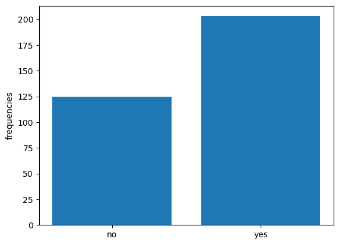

```python
plt.bar(levels, ni)
plt.ylabel('frequencies')
plt.show()
```

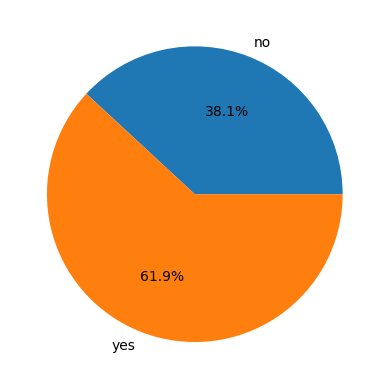

```python
plt.pie(ni, labels = levels, autopct='%1.1f%%')
plt.show()
```

### price

```python
x = np.array(df['price'][:])
```

#### Frequency table

```python
levels, ni = np.unique(x, return_counts = True)
fi = ni/n
Fi = np.cumsum(fi)
ft = pd.DataFrame(data = np.transpose([ni, fi, Fi]), index = levels, columns = ['frequencies', 'relative frequencies', 'cummulative relative frequencies'])
ft
```

|  | frequencies | relative frequencies | cummulative relative frequencies |
| --- | --- | --- | --- |
| 0.125 | 10.0 | 0.030488 | 0.030488 |
| 0.150 | 52.0 | 0.158537 | 0.189024 |
| 0.200 | 49.0 | 0.149390 | 0.338415 |
| 0.250 | 106.0 | 0.323171 | 0.661585 |
| 0.300 | 76.0 | 0.231707 | 0.893293 |
| 0.350 | 26.0 | 0.079268 | 0.972561 |
| 0.400 | 9.0 | 0.027439 | 1.000000 |

#### Graphics

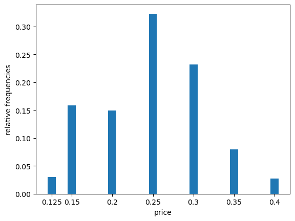

```python
positions = levels

plt.bar(positions, fi, width = 0.01)
plt.xticks(positions, levels)
plt.ylabel('relative frequencies')
plt.xlabel('price')
plt.show()
```

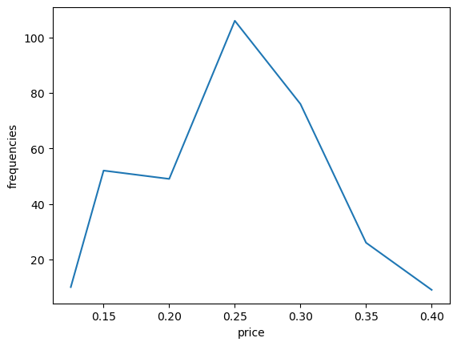

```python
plt.plot(positions, ni)
plt.ylabel('frequencies')
plt.xlabel('price')
plt.show()
```

#### Moments

```python
print(f'mean = {np.mean(x):.2f}, standard deviation = {np.std(x):.2f}')
```

```
mean = 0.25, standard deviation = 0.07
```

### quantity

```python
x = np.array(df['quantity'][:])
```

#### Frequency table

```python
min(x), max(x)
```

```
(4810, 76407)
```

```python
bins = np.array([    0.,  8000., 12000., 16000., 20000., 24000., 28000., 32000.,
       36000., 40000., 44000., 52000., 80000.])
bins, len (bins)
```

```
(array([    0.,  8000., 12000., 16000., 20000., 24000., 28000., 32000.,
        36000., 40000., 44000., 52000., 80000.]),
 13)
```

```python
ni, bins = np.histogram(x, bins = bins)
ni
```

```
array([ 6, 26, 41, 48, 57, 31, 36, 25, 22, 15, 12,  9])
```

```python
bins = np.array([0, 8000, 12000., 16000., 20000., 24000., 28000.,
        32000., 36000., 40000., 44000., 52000.,80000])
ni = np.histogram(x, bins = bins)[0]
ni
```

```
array([ 6, 26, 41, 48, 57, 31, 36, 25, 22, 15, 12,  9])
```

```python
lo = bins[:-1]
hi = bins[1:]
fi = ni/n
Fi = np.cumsum(fi)
```

```python
ft_quant = pd.DataFrame(data = np.transpose([lo, hi, ni, fi, Fi]), columns = ['lo', 'hi', 'frequencies', 'relative frequencies', 'cummulative relative frequencies'])
ft_quant
```

|  | lo | hi | frequencies | relative frequencies | cummulative relative frequencies |
| --- | --- | --- | --- | --- | --- |
| 0 | 0.0 | 8000.0 | 6.0 | 0.018293 | 0.018293 |
| 1 | 8000.0 | 12000.0 | 26.0 | 0.079268 | 0.097561 |
| 2 | 12000.0 | 16000.0 | 41.0 | 0.125000 | 0.222561 |
| 3 | 16000.0 | 20000.0 | 48.0 | 0.146341 | 0.368902 |
| 4 | 20000.0 | 24000.0 | 57.0 | 0.173780 | 0.542683 |
| 5 | 24000.0 | 28000.0 | 31.0 | 0.094512 | 0.637195 |
| 6 | 28000.0 | 32000.0 | 36.0 | 0.109756 | 0.746951 |
| 7 | 32000.0 | 36000.0 | 25.0 | 0.076220 | 0.823171 |
| 8 | 36000.0 | 40000.0 | 22.0 | 0.067073 | 0.890244 |
| 9 | 40000.0 | 44000.0 | 15.0 | 0.045732 | 0.935976 |
| 10 | 44000.0 | 52000.0 | 12.0 | 0.036585 | 0.972561 |
| 11 | 52000.0 | 80000.0 | 9.0 | 0.027439 | 1.000000 |

#### Graphics

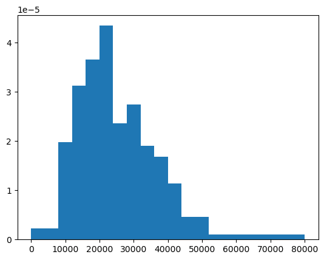

```python
plt.hist(x, bins, density = True)
plt.show()
```

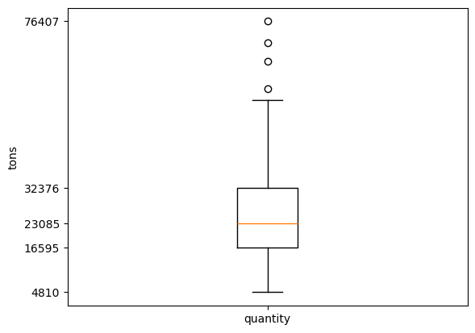

```python
alpha = [0, 0.25, 0.5, 0.75, 1]
q = np.quantile(x, alpha, method = 'inverted_cdf')
plt.boxplot(x)
plt.yticks(q,q)
plt.ylabel('tons')
plt.xticks([1], ['quantity'])
plt.show()
```

#### Moments

```python
print(f'mean = {np.mean(x):.2f}, standard deviation = {np.std(x):.2f}, skewness = {st.skew(x):.2f}, kurtosis = {st.kurtosis(x):.2f}')
```

```
mean = 25384.39, standard deviation = 11615.02, skewness = 0.98, kurtosis = 1.38
```

We have a large positive skew, and large kurtosis, we anticipate that this distribution is not Gaussian.

## Part III: confidence intervals

### Confidence interval for a proportion: the ice

```python
x = np.array(df['ice'][:])
levels, ni = np.unique(x, return_counts = True)
fi = ni/n
ft = pd.DataFrame(data = np.transpose([ni, fi]), index = levels, columns = ['frequencies', 'relative frequencies'])
ft
```

|  | frequencies | relative frequencies |
| --- | --- | --- |
| no | 188.0 | 0.573171 |
| yes | 140.0 | 0.426829 |

We make a confidence interval for the probability of prensence of ice at the Great Lakes. The estimated proportion (point estimate) is p0 = 0.426829 and we give a 95% estimate of this proportion.

```python
p0 = fi[1]
p0
```

```
0.4268292682926829
```

```python
alpha = 0.05
u = st.norm.ppf(1-alpha/2)
t = u * np.sqrt(p0*(1-p0)/n)
print(f'the proportion of weeks with ice at the Great Lakes is in ({p0-t:.2f},{p0+t:.2f}) with confidence level 95%')
```

```
the proportion of weeks with ice at the Great Lakes is in (0.37,0.48) with confidence level 95%
```

### Confidence level for a variance

For these data, we cannot construct a confidence interval for variance. This is possible only for Gaussian distributions and we have non here.

### Confidence interval for a mean: the quantity

We are interested to understand how low can be the sold quantities in a week. For this we construct a one right-sided confidence interval at a confidence level of 90%.

```python
x = np.array(df['quantity'][:])
bx = np.mean(x)
bx
```

```
25384.393292682926
```

```python
s = np.std(x, ddof = 1)
alpha = 0.1
u = st.norm.ppf(1-alpha)
t = u*s/np.sqrt(n)
print(f'the mean of tons of grain sold by week is greater than {bx-t:.2f} with confidencelevel 90%')
```

```
the mean of tons of grain sold by week is greater than 24561.24 with confidencelevel 90%
```

## Part IV: Goodness-of-fit test

**Nota bene**: when dealing with some distribution that you do not know but have identified, you must be able to estimate its parameters. Usually, this is given on Wikipedia (or of course in Stitistics books). You always have to write a word about the estimation of the parameters. More over, you have to estimate the parameter that are used in `scipy.stats` for the theoretical distribution you are comparing your distribution to, not others.

### Fitting the quantity to a Gamma distribution

I estimate the parameters by the method of moments:

$$\hat\beta = \frac{\overline X}{S^2},\quad \hat\alpha = \hat\beta\; \overline X.$$

```python
x = np.array(df['quantity'][:])
```

#### The theoretical distribution

```python
# parameters point estimates
bx = np.mean(x)
s2 = np.var(x, ddof = 1)
beta = bx/s2
alpha = beta*bx
```

```python
# defining (freezing) the target distribution
dist = st.gamma(alpha,  scale = 1/beta)
```

#### Graphical fit

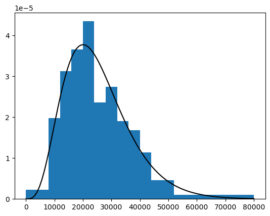

```python
bins = np.array([ 0, 8000., 12000., 16000., 20000., 24000., 28000., 32000., 36000.,
       40000., 44000., 52000., 80000])
t = np.linspace(0,80000, 100)
plt.hist(x, bins, density = True)
plt.plot(t,dist.pdf(t), 'k')
plt.show()
```

We conclude that this distribution is a potential modem for our distribution and we try the chi-squared goodness-of-fit test with 2 estimated parameters.

#### Classes and empirical frequencies of classes

```python
ni = np.array(ft_quant.frequencies)
# number of classes
J = len(ni)
```

#### Theoretical frequencies of classes

```python
Fi = dist.cdf(bins)
npi = np.diff(Fi)
npi[0] = Fi[1]
npi[-1] = 1-Fi[-2]
npi = n*npi
```

#### Chi-squared value and test

The actal normalized distance between the to distibutions has approximately a chi-squared distribution with $J-1-2$ degress of freedom under the assumption $H_0$ of adequation of distributions. The $p$-value of the test is the probability of having at least such distance under the assumption $H_0$. We make a test at a significance level of $\alpha =$10%

```python
di = (ni-npi)**2/npi
d = np.sum(di)
pvalue = st.chi2.sf(d, J-1-2)
pvalue
```

```
0.6326299364074179
```

The $p$-value is far grater than $\alpha$. This means that there is no significant prove to reject $H_0$ and we consider that the fit is correct.

## Part V: more tests

### A chi-squared test to compare samples

Chi-squared test is also used for comparing samples. Hrer, for instance, we can compare the distribution of quantities with and without cartel. If the distributions are different, it will make further analysis more difficult so we hope see that the distributions are not significantly different, i.e. to have a $p$-value larger that 0.05.

```python
dfc = df[df['cartel'] == 'yes']
dfc
```

|  | rownames | price | cartel | quantity | season | ice |
| --- | --- | --- | --- | --- | --- | --- |
| 0 | 1 | 0.40 | yes | 13632 | Jan 1 - Jan 28 | yes |
| 1 | 2 | 0.40 | yes | 20035 | Jan 1 - Jan 28 | yes |
| 2 | 3 | 0.40 | yes | 16319 | Jan 1 - Jan 28 | yes |
| 3 | 4 | 0.40 | yes | 12603 | Jan 1 - Jan 28 | yes |
| 4 | 5 | 0.40 | yes | 23079 | Jan 29 - Feb 25 | yes |
| ... | ... | ... | ... | ... | ... | ... |
| 323 | 324 | 0.25 | yes | 19686 | Feb 26 - Mar 26 | yes |
| 324 | 325 | 0.25 | yes | 14757 | Mar 27 - Apr 23 | yes |
| 325 | 326 | 0.25 | yes | 16502 | Mar 27 - Apr 23 | yes |
| 326 | 327 | 0.25 | yes | 11490 | Mar 27 - Apr 23 | yes |
| 327 | 328 | 0.25 | yes | 7843 | Mar 27 - Apr 23 | yes |

203 rows × 6 columns

```python
dfnc = df[df['cartel'] == 'no']
dfnc
```

|  | rownames | price | cartel | quantity | season | ice |
| --- | --- | --- | --- | --- | --- | --- |
| 61 | 62 | 0.35 | no | 17494 | Feb 26 - Mar 26 | yes |
| 62 | 63 | 0.35 | no | 16260 | Feb 26 - Mar 26 | yes |
| 63 | 64 | 0.35 | no | 26690 | Feb 26 - Mar 26 | yes |
| 64 | 65 | 0.35 | no | 21723 | Mar 27 - Apr 23 | yes |
| 65 | 66 | 0.35 | no | 30625 | Mar 27 - Apr 23 | yes |
| ... | ... | ... | ... | ... | ... | ... |
| 318 | 319 | 0.25 | no | 17868 | Jan 29 - Feb 25 | yes |
| 319 | 320 | 0.25 | no | 22789 | Jan 29 - Feb 25 | yes |
| 320 | 321 | 0.25 | no | 34851 | Feb 26 - Mar 26 | yes |
| 321 | 322 | 0.25 | no | 29997 | Feb 26 - Mar 26 | yes |
| 322 | 323 | 0.25 | no | 34010 | Feb 26 - Mar 26 | yes |

125 rows × 6 columns

We adjust bins in order taht the two distributions have frequencies over 5 in each class

```python
bins = np.array([0, 14000., 16000., 20000., 24000., 28000.,
        32000., 36000., 40000., 44000., 80000])
```

```python
x = np.array(dfc.quantity)
nic = np.histogram(x, bins = bins)[0]
nic
```

```
array([43, 15, 37, 42, 13, 16, 14,  8,  7,  8])
```

```python
y = np.array(dfnc.quantity)
ninc = np.histogram(y, bins = bins)[0]
ninc
```

```
array([ 7,  8, 11, 15, 18, 20, 11, 14,  8, 13])
```

We can already see that the tails look different.

```python
nkj = np.vstack((nic, ninc))
nk = np.sum(nkj, axis = 1)
nj = np.sum(nkj, axis = 0)
ddl = (np.shape(nkj)[0]-1)*(np.shape(nkj)[1]-1)
nkj, nk, nj, ddl
```

```
(array([[43, 15, 37, 42, 13, 16, 14,  8,  7,  8],
        [ 7,  8, 11, 15, 18, 20, 11, 14,  8, 13]]),
 array([203, 125]),
 array([50, 23, 48, 57, 31, 36, 25, 22, 15, 21]),
 9)
```

The chi-squared statistic is

```python
nkj_th = np.tensordot(nk,nj, axes = 0)/n
```

```python
dkj = (nkj- nkj_th)**2/nkj_th
d2 =  np.sum(dkj)
d2
```

```
43.3291792104306
```

```python
p_value =st.chi2.sf(d2, ddl)
p_value
```

```
1.875471412699087e-06
```

Drat! The $p$-value is small, which means that the distributions are significantly different. It means that there is prbably a confounding factor somewhere because there is no reason why the existence of a cartel should change the quantity (it changes the price).

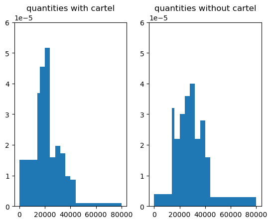

```python
plt.subplot(1,2,1)
plt.hist(x,bins, density = True)
plt.title('quantities with cartel')
plt.ylim(0, 6*10**(-5))
plt.subplot(1,2,2)
plt.hist(y, bins, density = True)
plt.title('quantities without cartel')
plt.ylim(0, 6*10**(-5))
plt.show()
```

Of course many other analyses can be done with this method.

### A parametric test to compare the means of two samples

Here the two samples are not Gaussian, therefore we cannot compare the variance with a Fisher test but we cal still compare the mean.

```python
bx, sx2, nx = np.mean(x), np.var(x, ddof = 1), len(x)
by, sy2, ny = np.mean(y), np.var(y, ddof = 1), len(y)
t = (bx-by)*np.sqrt(n-2)/np.sqrt((nx-1)*sx2+(ny-1)*sy2)/np.sqrt(1/nx+1/ny)
p_value = 2*st.t.sf(np.abs(t), n-2)
p_value
```

```
8.791886948731072e-09
```

As expected, we reject the equality of means.